# Fit Blue Presentation

# 1 Abstract

# 2 Descriptive Analysis

## 2.1 Demographics

All particpants in the study were on active duty in the military and had to have at least one year left at the Air Force base so that they would likely be available in person for the 4 and 12 month follow-ups. The requirements for participation were as follows: 18 years or older, BMI greater or equal to 25.0, access to computer and email, and cleared to participate by a healthcare provider.

|  | Number of Participants CI | Number of Participants SI | Total(%) |
| --- | --- | --- | --- |
| **Gender** |  |  |  |
| Female | 53 | 46 | 99(51.8 %) |
| Male | 50 | 42 | 92(48.2 %) |
| **Race** |  |  |  |
| African American | 22 | 16 | 38(19.9 %) |
| Caucasian American | 65 | 61 | 126(66.0 %) |
| Other | 16 | 11 | 27(14.1 %) |
| **Education** |  |  |  |
| Less than College | 46 | 44 | 90(47.1 %) |
| College or Above | 57 | 44 | 101(52.9 %) |
| **BMI Category** |  |  |  |
| Overweight (BMI: 25-29.9) | 51 | 37 | 88(46.1 %) |
| Obese (BMI: 30+) | 52 | 51 | 103(53.9 %) |
| **Age** |  |  |  |
| Age (mean, sd) | 35.5(8.2) | 33.9(6.8) | 34.8(7.6) |

## 2.2 Summary Weight Change Table

|  | Counselor-Initiated | Self-Initiated |
| --- | --- | --- |
| 4 Month (mean, median, sd) | -3.7, -3.4, 3.6 | -0.6, -0.1, 3.1 |
| 12 Month (mean, median, sd) | -2.4, -2.1, 5 | 0.2, 0.2, 5.1 |

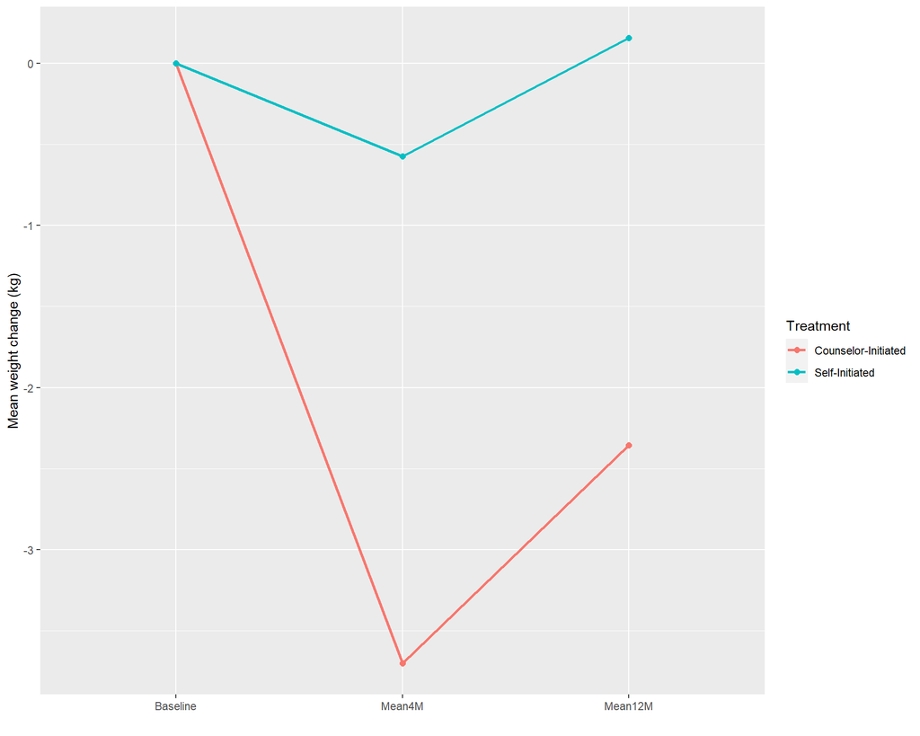

## 2.3 Average % Days Logged-in

Login Days decreased steadily over the course of the study. Weekend and Weekday logins tended to follow the same trends with peaks and falls in the average logins. The increase at week 46 aligns with the participants’ receivals of reminder cards about the upcoming 12 month weigh-in

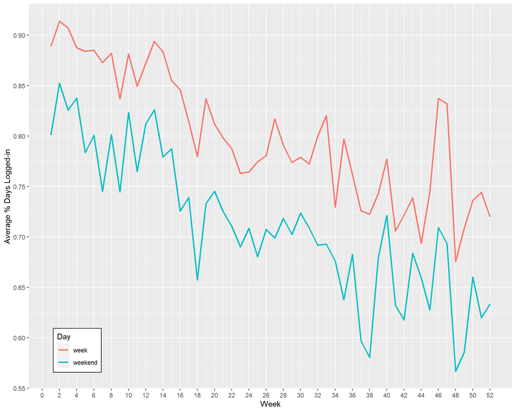

## 2.4 Number of Login Days in the First 4 Weeks

Trends within treatment groups are apparent. Counselor-Initiated groups have similar login habits in the first 4 weeks while Self-Initiated groups have more similar login habits regardless of Success. Logins are just starting to decrease in the unsuccessful Counselor-Initiated group in the fourth week which led us to believe there may be a reason to explore the first 8 weeks of the study. Another point to note is that consistent logins in the first 4 weeks didn’t seem to be a predictor of successful weight loss for self-initiated people.

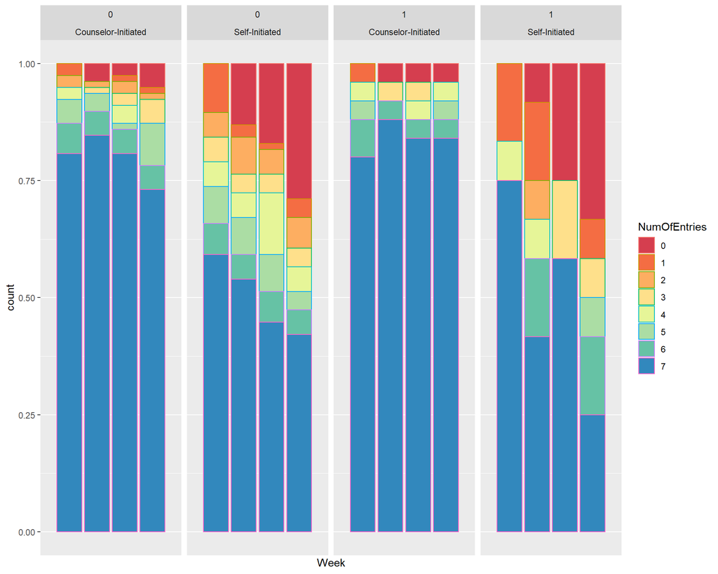

## 2.5 Number of Login Days in the first 8 weeks

- When looking at the first 8 weeks, it is easier to see the trends among groups. The Counselor-initiated Success group still looks to be the most stable in terms of days logged in
- The Self-Initiated Success group began to level out after the 4th week whereas the unsuccessful Self-Initiated group’s logins continued to decrease
- The Counselor-Initiated unsuccessful group remained high in logins but there was more variability in the number of logins between weeks.

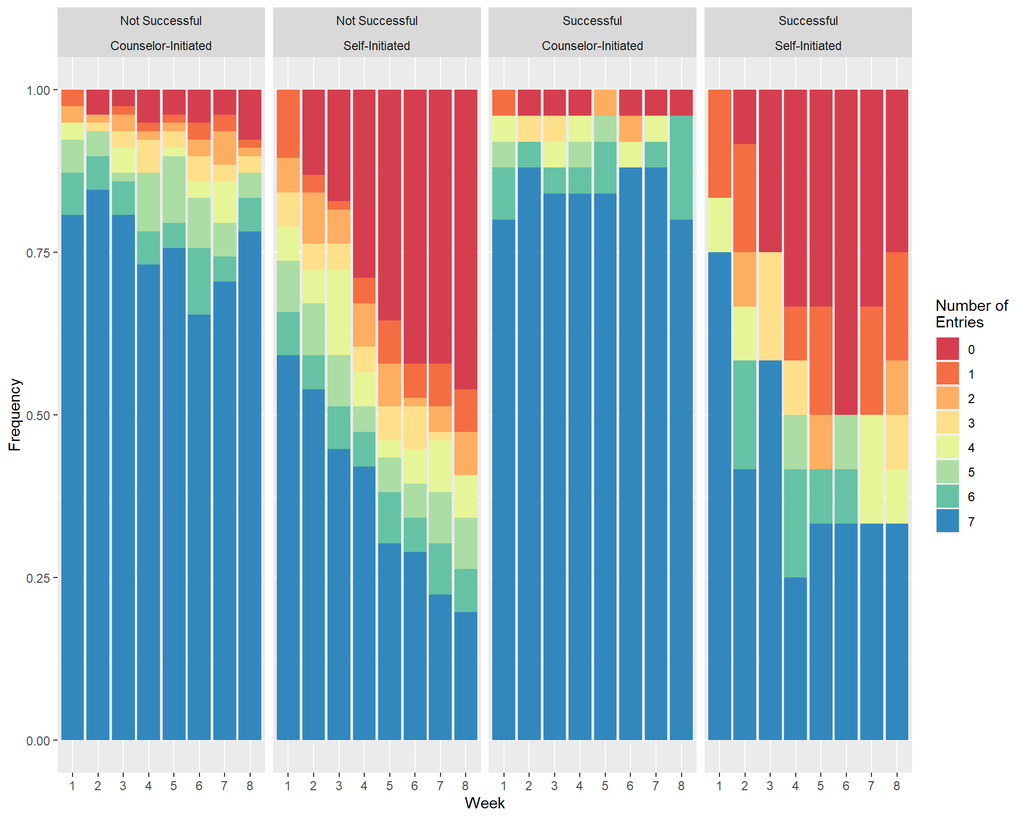

## 2.6 Number of Login Days in 4 months

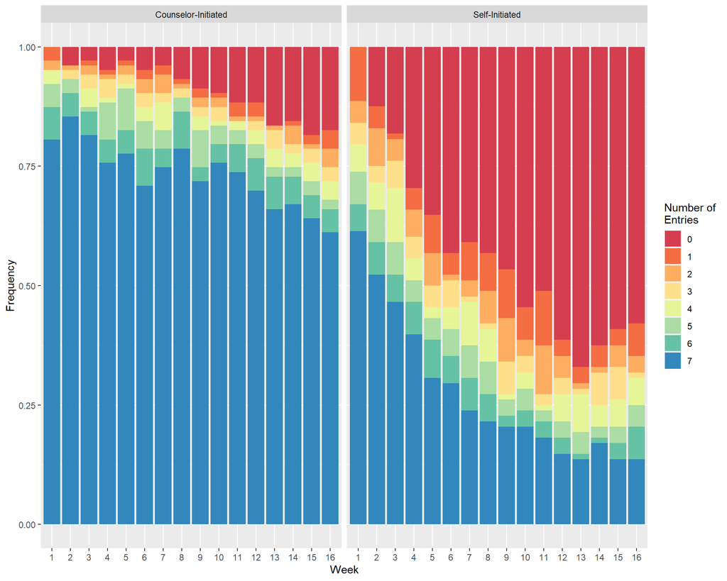

## 2.7 Average Weekly Entries among Weight Loss Categories

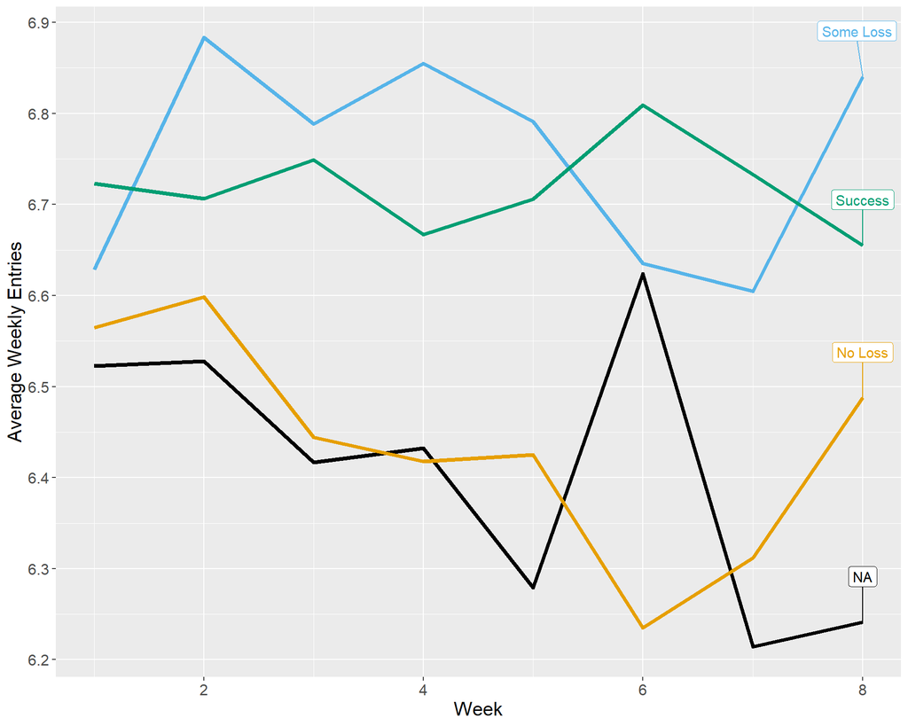

# 3 Linear Regression with Training on PCA

Our outcome variables of weight change at 4 and 12 months were modeled as the log difference of the starting weight and final weight at 4 and 12 months. We conducted the analysis in R. We used the package FactoMineR to perform principal component analysis (PCA) on the data to reduce dimension and eliminate correlation between variables by creating new uncorrelated, orthogonal variables known as principal components (PCs).

Variables used to conduct PCA: Treatment, Age, Gender, log of the individual’s Initial Weight, Number of Self-Weigh-ins, Total Entries, Total Food Days, Total Exercise Days, Total Breakfast, Lunch, Dinner, and Snack Days, Frequency of Breakfast, Lunch, Dinner, and Snack Recorded, Average Total Calories, Average Exercise Calories, Average Breakfast, Lunch, Dinner, and Snack Calories, Average Breakfast, Lunch, Dinner, and Snack Words.

In order to cross validate, we first divided the data into 5 folds We performed PCA on the data in 4 of the folds, trained the model on those PCs, and predicted the log weight change for the data in the fifth fold. We recorded the predictions then repeated the analysis with a permutation of folds until all data points have been predicted. Finally plot the actual vs. predicted log weight change and determine the r-squared value.

Regardless of whether we built the models without PCA variables or with PCA or with random forest analysis or linear regression, 4 month predictions always had a higher r-squared value compared to 12 month predictions. We drew several conclusions from this analysis

- The predictors we included in our analysis are more accurate predictors for 4 month analysis, so there may either be better predictors for 12 month weight change that are different than the 4 month predictors or using the data from the first 4 and 8 weeks is not sufficient information to predict 12 month weight change.
- Models tend to underpredict Success. Especially for 12 month predictions, the models are very conservative in how much they predict an individual will lose.

## 3.1 Predict 4 Month with 1-4 Weeks

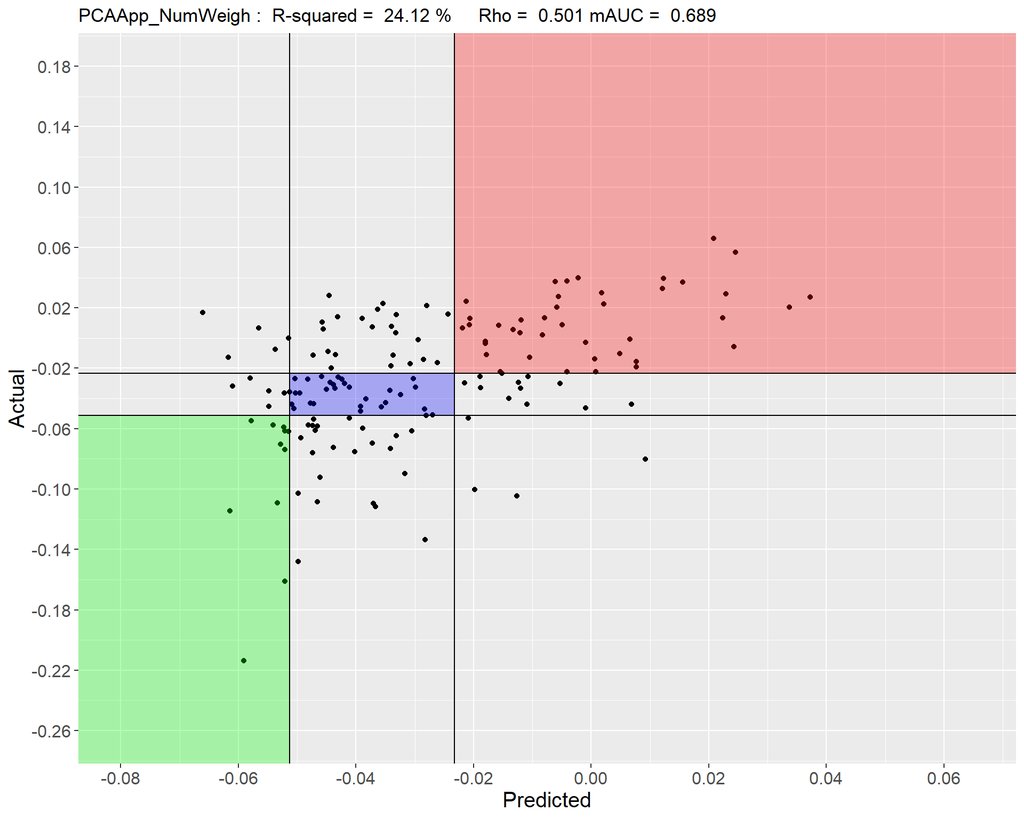

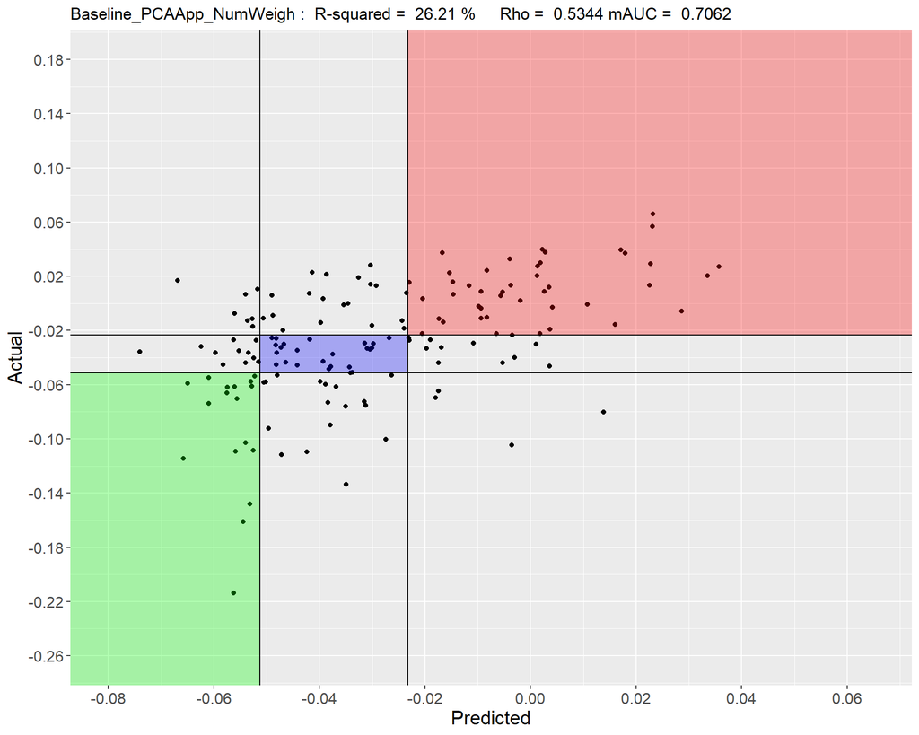

```
##
## $tradNoPCA
## $tradNoPCA$rsquared
## [1] 16.44
##
## $tradNoPCA$plot
```

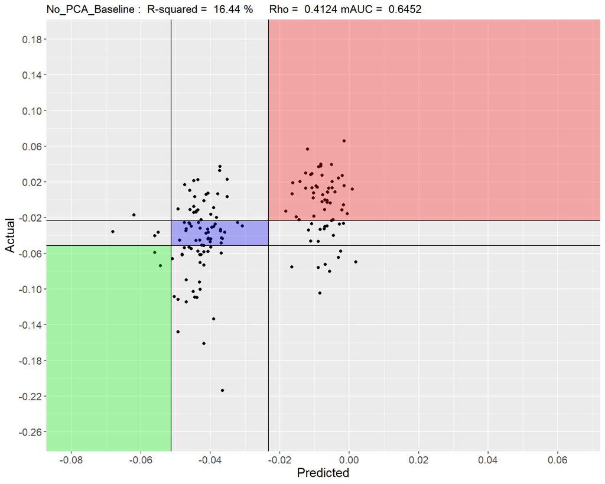

## 3.2 Predict 4 Month with 1-8 Weeks

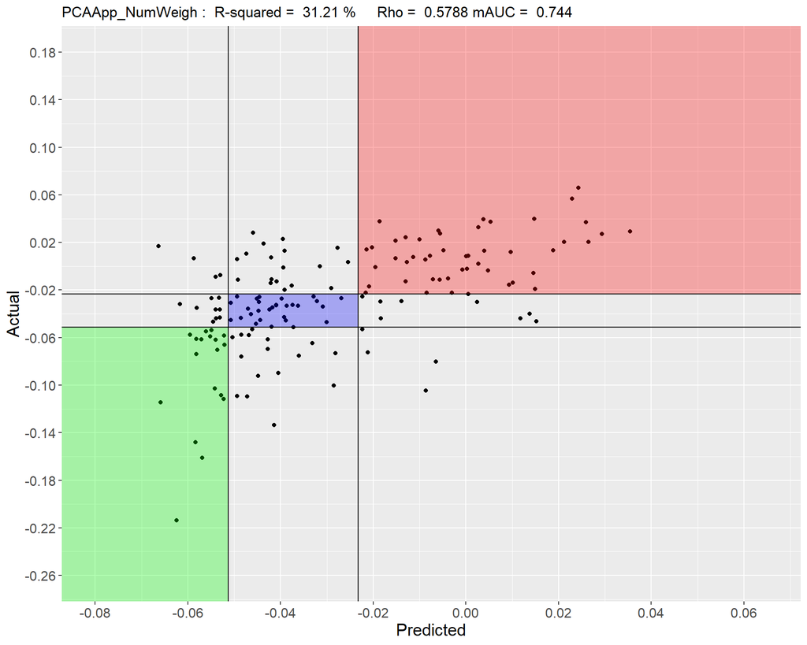

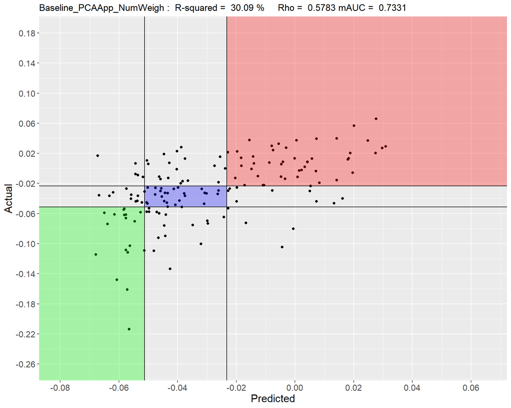

```
##
## $tradNoPCA
## $tradNoPCA$rsquared
## [1] 16.44
##
## $tradNoPCA$plot
```

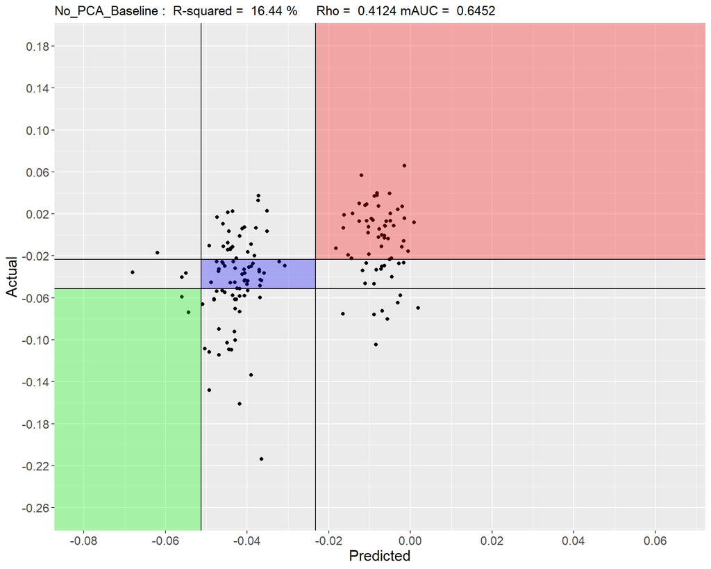

## 3.3 Predict 12 Month with 1-4 Weeks

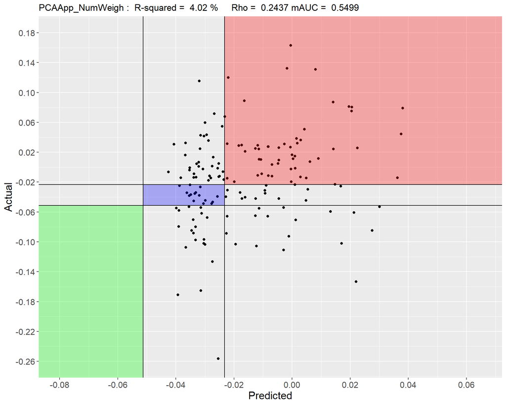

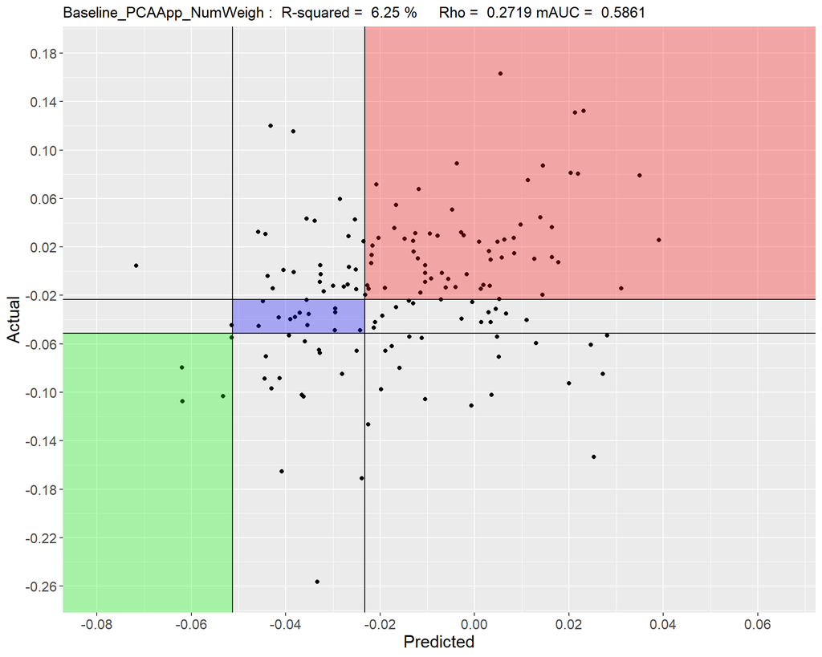

```
##
## $tradNoPCA
## $tradNoPCA$rsquared
## [1] 5.75
##
## $tradNoPCA$plot
```

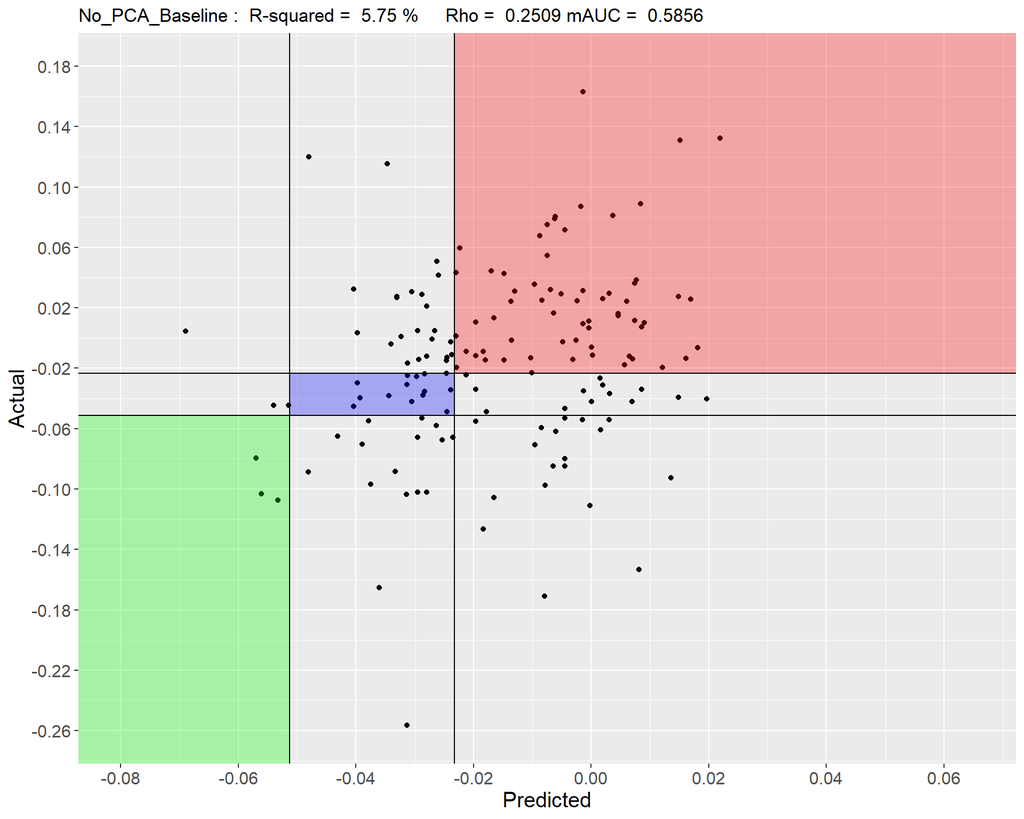

## 3.4 Predict 12 Month with 1-8 Weeks

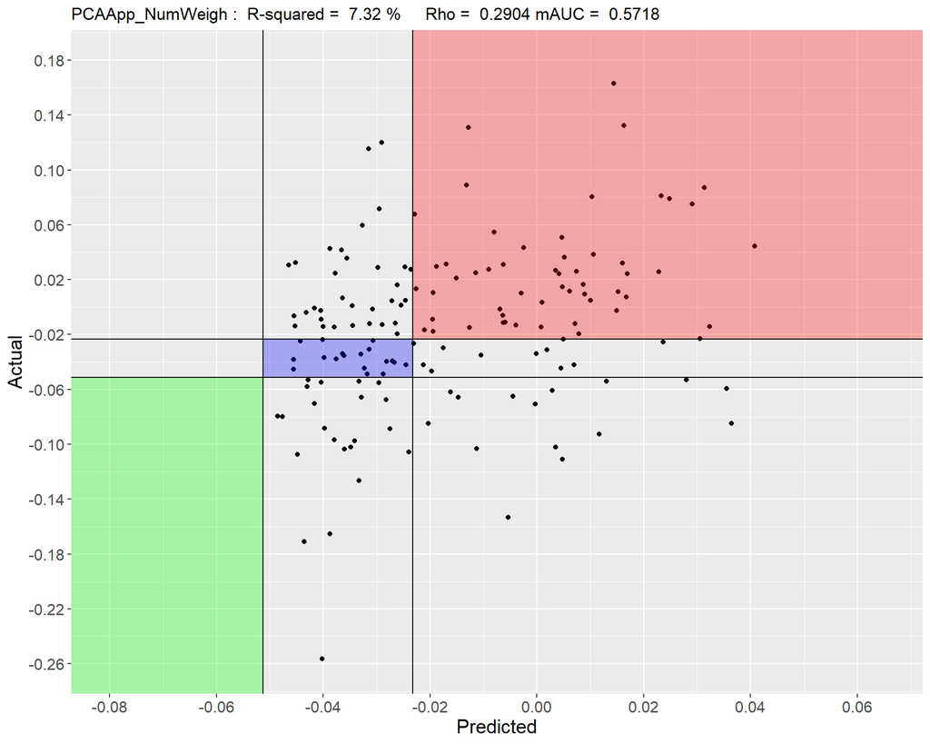

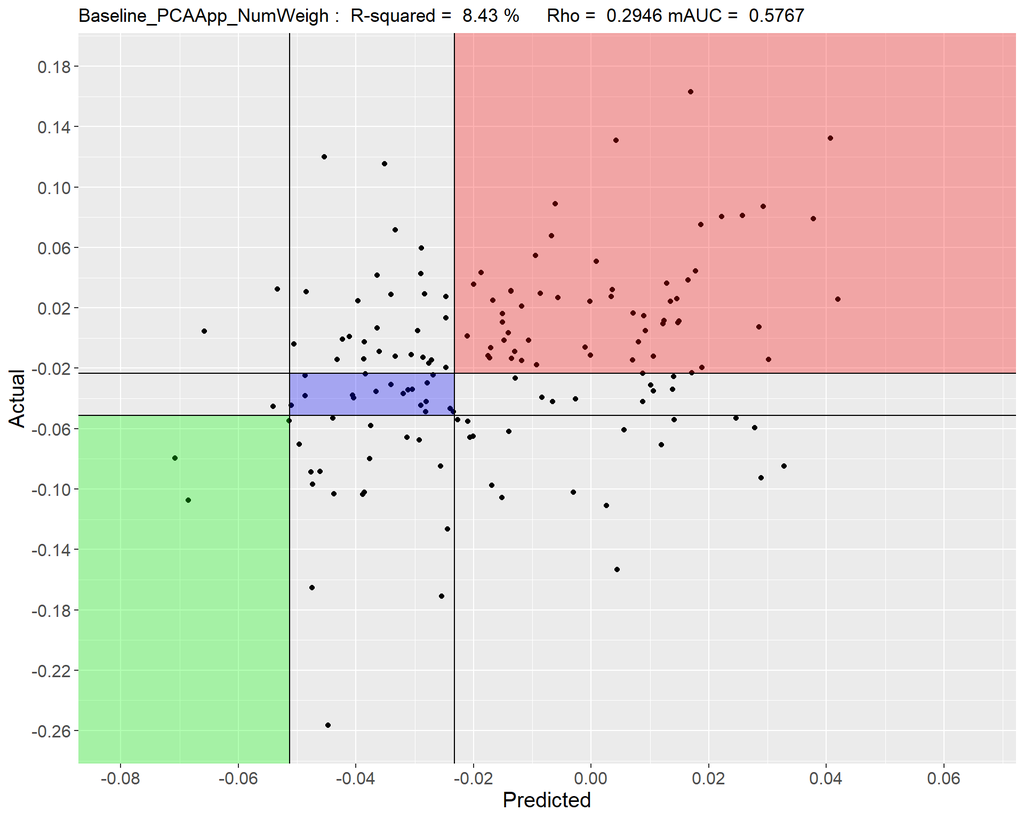

```
##
## $tradNoPCA
## $tradNoPCA$rsquared
## [1] 5.75
##
## $tradNoPCA$plot
```

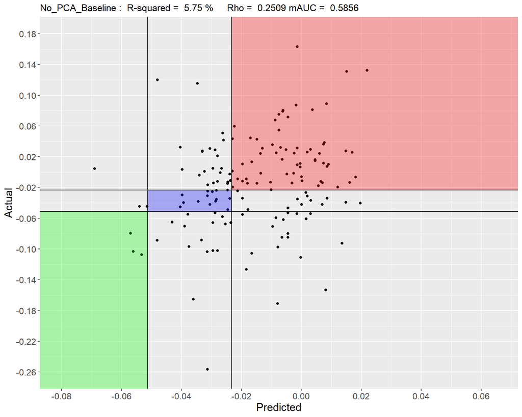

# 4 PCA Results

## 4.1 4 Weeks

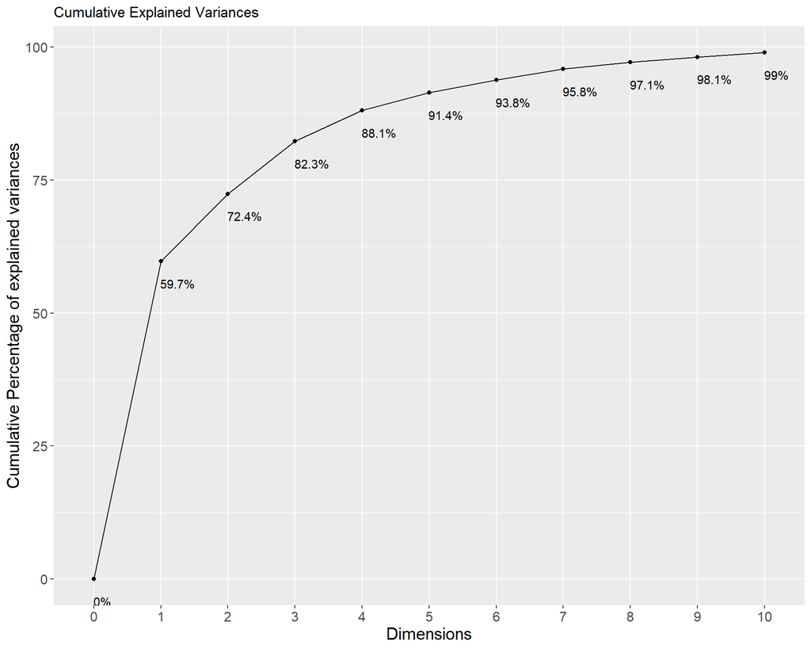

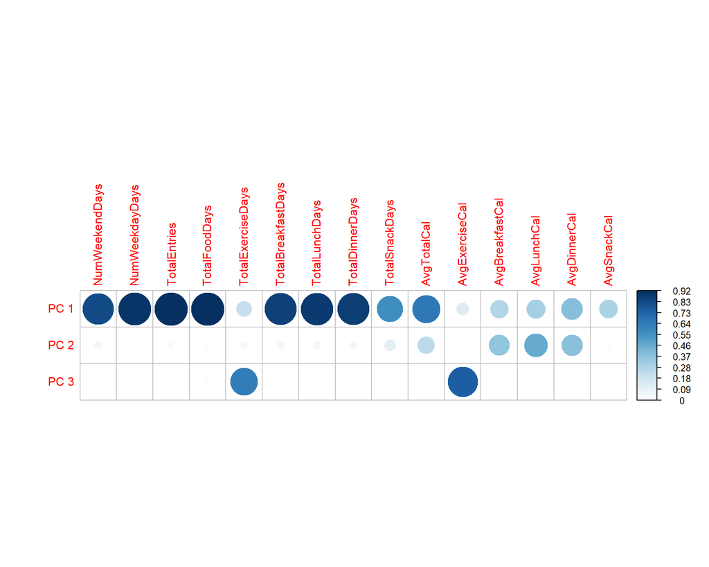

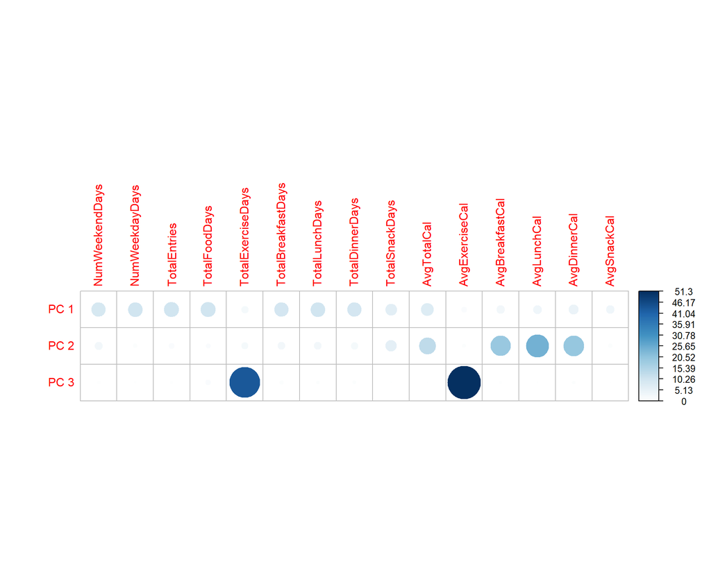

## 4.2 8 Weeks

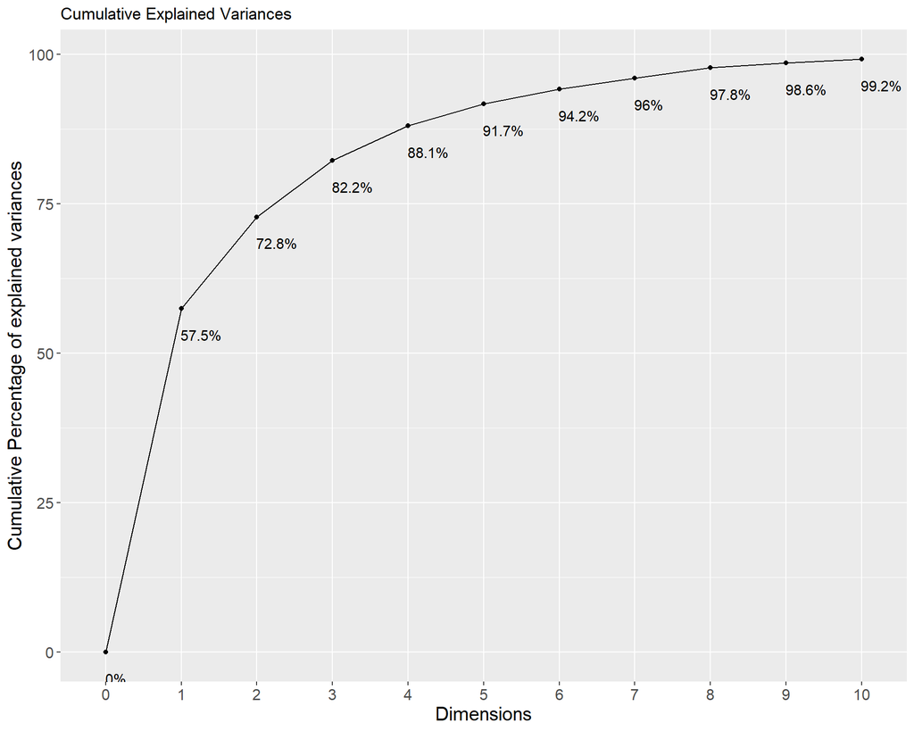

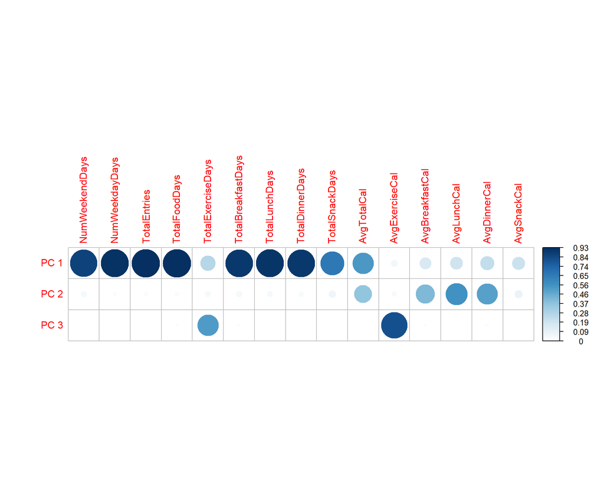

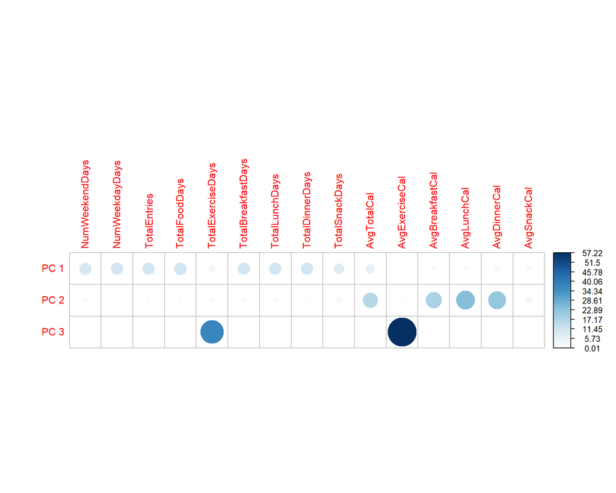

# 5 Linear Regression on First 8 Weeks predicting 4 Month Weight Loss with PCA App vars and baseline

```
##
## Call:
## lm(formula = -WeightLoss4Month ~ Dim.1 + Dim.2 + Treatment +
##     Age + NumWeigh, data = Allreg.data)
##
## Residuals:
##       Min        1Q    Median        3Q       Max
## -0.087097 -0.023232 -0.003425  0.011510  0.155472
##
## Coefficients:
##               Estimate Std. Error t value Pr(>|t|)
## (Intercept) -0.0189189  0.0166057  -1.139  0.25642
## Dim.1        0.0045135  0.0013531   3.336  0.00108 **
## Dim.2        0.0062062  0.0020596   3.013  0.00304 **
## Treatment    0.0087133  0.0073053   1.193  0.23488
## Age          0.0003977  0.0003969   1.002  0.31792
## NumWeigh     0.0006576  0.0002410   2.729  0.00713 **
## ---
## Signif. codes:  0 '***' 0.001 '**' 0.01 '*' 0.05 '.' 0.1 ' ' 1
##
## Residual standard error: 0.0359 on 148 degrees of freedom
##   (37 observations deleted due to missingness)
## Multiple R-squared:  0.3411, Adjusted R-squared:  0.3189
## F-statistic: 15.32 on 5 and 148 DF,  p-value: 3.974e-12
```

```
##
## Call:
## lm(formula = -WeightLoss4Month ~ Dim.1 + Dim.2 + Dim.3 + Treatment +
##     Age + NumWeigh, data = Allreg.data)
##
## Residuals:
##       Min        1Q    Median        3Q       Max
## -0.085812 -0.022916 -0.003635  0.012097  0.155985
##
## Coefficients:
##               Estimate Std. Error t value Pr(>|t|)
## (Intercept) -0.0177190  0.0167919  -1.055  0.29306
## Dim.1        0.0045340  0.0013568   3.342  0.00106 **
## Dim.2        0.0062676  0.0020676   3.031  0.00288 **
## Dim.3       -0.0013153  0.0024256  -0.542  0.58846
## Treatment    0.0085649  0.0073279   1.169  0.24437
## Age          0.0003639  0.0004027   0.904  0.36763
## NumWeigh     0.0006578  0.0002415   2.723  0.00725 **
## ---
## Signif. codes:  0 '***' 0.001 '**' 0.01 '*' 0.05 '.' 0.1 ' ' 1
##
## Residual standard error: 0.03598 on 147 degrees of freedom
##   (37 observations deleted due to missingness)
## Multiple R-squared:  0.3424, Adjusted R-squared:  0.3156
## F-statistic: 12.76 on 6 and 147 DF,  p-value: 1.444e-11
```

# 6 Linear Regression on First 8 Weeks predicting 12 Month Weight Loss with PCA App vars and baseline

```
##
## Call:
## lm(formula = -WeightLoss12Month ~ Dim.1 + Dim.2 + Treatment +
##     Age + NumWeigh, data = Allreg.data)
##
## Residuals:
##       Min        1Q    Median        3Q       Max
## -0.159691 -0.033494 -0.001708  0.033363  0.205881
##
## Coefficients:
##               Estimate Std. Error t value Pr(>|t|)
## (Intercept) -0.0669211  0.0261883  -2.555   0.0116 *
## Dim.1        0.0029612  0.0020485   1.446   0.1504
## Dim.2        0.0040086  0.0031757   1.262   0.2088
## Treatment    0.0062718  0.0112054   0.560   0.5765
## Age          0.0013447  0.0006079   2.212   0.0285 *
## NumWeigh     0.0007839  0.0003768   2.080   0.0392 *
## ---
## Signif. codes:  0 '***' 0.001 '**' 0.01 '*' 0.05 '.' 0.1 ' ' 1
##
## Residual standard error: 0.05613 on 147 degrees of freedom
##   (38 observations deleted due to missingness)
## Multiple R-squared:  0.1606, Adjusted R-squared:  0.132
## F-statistic: 5.625 on 5 and 147 DF,  p-value: 8.957e-05
```

```
##
## Call:
## lm(formula = -WeightLoss12Month ~ Dim.1 + Dim.2 + Dim.3 + Treatment +
##     Age + NumWeigh, data = Allreg.data)
##
## Residuals:
##      Min       1Q   Median       3Q      Max
## -0.16762 -0.03469 -0.00339  0.03337  0.19993
##
## Coefficients:
##               Estimate Std. Error t value Pr(>|t|)
## (Intercept) -0.0697434  0.0260650  -2.676  0.00831 **
## Dim.1        0.0028890  0.0020353   1.419  0.15789
## Dim.2        0.0036558  0.0031611   1.156  0.24937
## Dim.3        0.0067296  0.0038982   1.726  0.08640 .
## Treatment    0.0078897  0.0111701   0.706  0.48111
## Age          0.0014667  0.0006079   2.413  0.01708 *
## NumWeigh     0.0007404  0.0003751   1.974  0.05031 .
## ---
## Signif. codes:  0 '***' 0.001 '**' 0.01 '*' 0.05 '.' 0.1 ' ' 1
##
## Residual standard error: 0.05575 on 146 degrees of freedom
##   (38 observations deleted due to missingness)
## Multiple R-squared:  0.1774, Adjusted R-squared:  0.1436
## F-statistic: 5.247 on 6 and 146 DF,  p-value: 6.378e-05
```

# 7 Future Studies

A topic for future study on this data would be on how weight loss changed from month 4 to month 12. For example, over half of the participants who were successful at the 4th month benchmark ended up gaining some back. Additionally, most of the people who hadn’t lost weight by the 4th month didn’t lose weight by the 12th month either.

As seen in the analysis section, our models were not as successful at predicting 12 month weight change. The following graphs show why it is a hard task. There is a lot that happens between months 4 and 12. Some who had successfully lose weight, gained it back while others who hadn’t lost weight at 4 months successfully lost weight at 12 months.

## 7.1 Predicting 12 Month Weight Loss with 4 Month Weight Loss

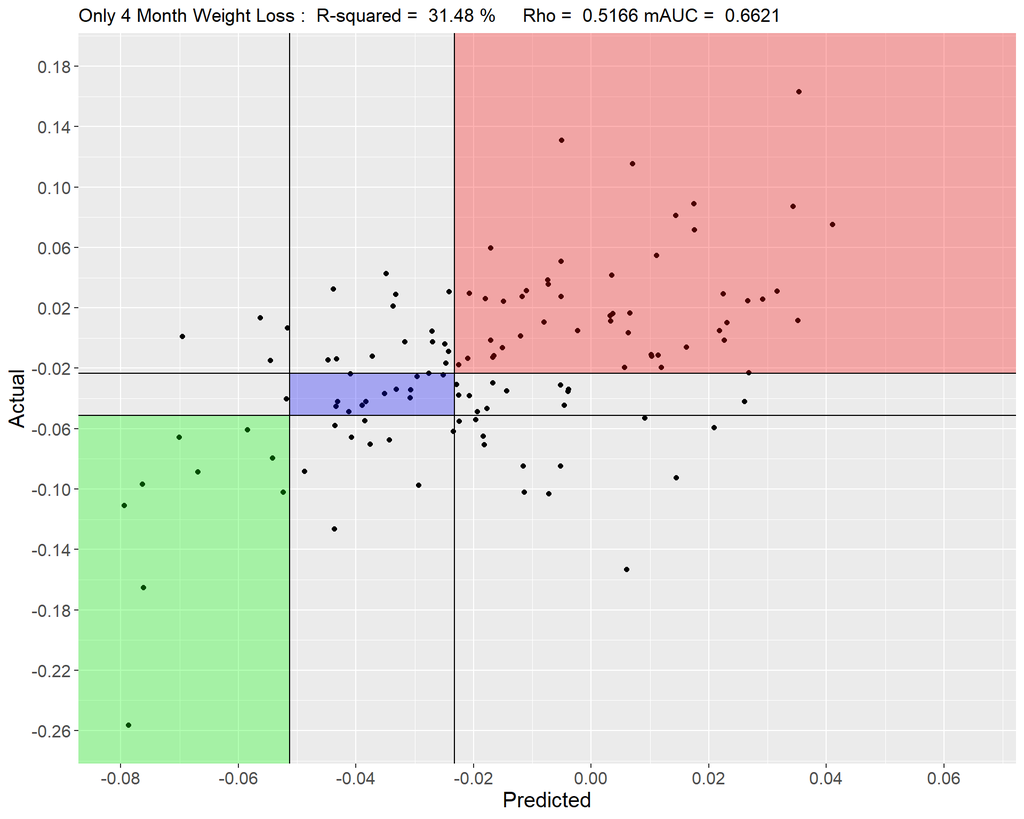

```
##          Length Class  Mode
## rsquared 1      -none- numeric
## plot     9      gg     list
```

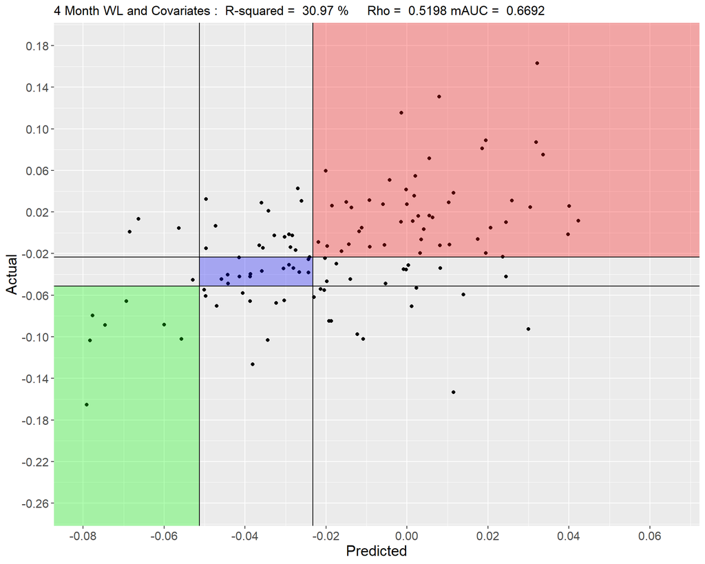

```
##          Length Class  Mode
## rsquared 1      -none- numeric
## plot     9      gg     list
```

Another topic for future analysis is using the breakfast, lunch, dinner, and snack descriptions provided by the participants to analyze the foods individuals consumed. Researchers can use a package such as R’s text2vec to do some text-processing and analyze trends in an individual’s diet to see how it relates to their weight loss.